# How accelerometers, gyroscopes and magnetometers data can tell us whether people exercise correctly

Nathalie Descusse-Brown

April 04, 2019

## Executive Summary

This paper makes use of data from accelerometers, gyroscopes and magnetometers on the belt, forearm, arm, and dumbell of 6 participants. These participants were asked to perform barbell lifts correctly and incorrectly in 5 different ways. The aim of this paper is to use the data to predict the manner in which the participants did the exercise. More information is available from the website here: http://groupware.les.inf.puc-rio.br/har (see the section on the Weight Lifting Exercise Dataset).

## Data Processing

The training dataset was accessed at the following site and assigned to the train tibble: https://d396qusza40orc.cloudfront.net/predmachlearn/pml-training.csv

The testing dataset was accessed at the following site and assigned to the test tibble: https://d396qusza40orc.cloudfront.net/predmachlearn/pml-testing.csv

```r
## load all data necessary to the assignment
library(tidyverse)

if (!file.exists("pml-training.csv")) {
  fileUrl1 <- "https://d396qusza40orc.cloudfront.net/predmachlearn/pml-training.csv"
download.file(fileUrl1,destfile="pml-training.csv")
fileUrl2 <- "https://d396qusza40orc.cloudfront.net/predmachlearn/pml-testing.csv"
download.file(fileUrl2,destfile="pml-testing.csv")
}
train <- read_csv("pml-training.csv")
test <- read_csv("pml-testing.csv")
```

## Exploratory Analysis

We know from the data source that the data is classified as follows: - Class A: performed exactly according to the specification - Class B: throwing the elbows to the front - Class C: lifting the dumbbell only halfway - Class D: lowering the dumbbell only halfway - Class E: throwing the hips to the front.

As there are 160 columns, the tibble train was first tidied up by removing the columns with a significant number of NA, empty, or #DIV/0! values. This leaves only 60 columns, which will significantly improve processing time. The first two columns of the train datasets were also removed as not necessary for model fitting. The test dataset was processed in a similar manner in view of making predictions.

```r
library(plyr)
library(Hmisc)


tidytrain <- data.frame(stringsAsFactors=FALSE)
tidytest <- data.frame(stringsAsFactors=FALSE)

j <- 1
for (i in 1:dim(train)[2])
        {
                if (((count(is.na(train[,i]))[[1,2]]>11773) & (count(train[,i]=="")[[1,2]]>7849) & (count(train[,i]=="#DIV/0!")[[1,2]]>7849)) & length(tidytrain)==0)
                {
                        tidytrain <- train[,i]
                        tidytest <- test[,i]
                        # firstname <- colnames(train)[i]
                        j <- j+1
                }
                else if (((count(is.na(train[,i]))[[1,2]]>11773) & (count(train[,i]=="")[[1,2]]>7849) & (count(train[,i]=="#DIV/0!")[[1,2]]>7849)) & length(tidytrain)>0)
                {
                        tidytrain <- cbind(tidytrain,train[,i])
                        tidytest <- cbind(tidytest,test[,i])
                        colnames(tidytrain)[j] <- colnames(train)[i]
                        colnames(tidytest)[j] <- colnames(test)[i]
                        j <- j+1
                }
        }

tidytrain <- tidytrain[,-c(1,2)]
tidytest <- tidytest[,-c(1,2)]
```

Because of the classification and the location of the measuring devices we make the following assumptions: - Class B should be associated with a negative gyros_dumbbell_z as the dumbell is pushed towards the shoulder when the elbow goes to the front. - Class C should be associated with smaller gyros_dumbbell_y and gyros_forearm_y compared to Class A and Class B. - Class D should be associated with similar amplitude gyros_dumbbell_y and gyros_forearm_y compared to Class C but shifted along the y axis. - Class E should be associated with larger gyros_belt_z compared to other classes.

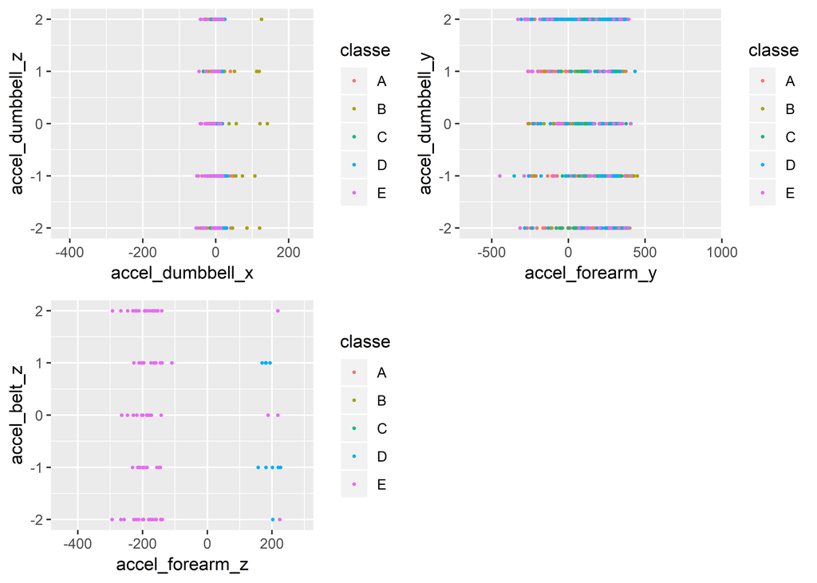

```r
library(gridExtra)

p = ggplot(tidytrain,aes(y=accel_dumbbell_z,x=accel_dumbbell_x,colour=classe))+geom_point(colour="grey50",size=0.5)+geom_point(size=0.5) + ylim(-2,2)
p2 = ggplot(tidytrain,aes(y=accel_dumbbell_y,x=accel_forearm_y,colour=classe))+geom_point(colour="pink",size=0.5)+
        geom_point(size=0.5) + ylim(-2,2)
p3 = ggplot(tidytrain,aes(y=accel_belt_z,x=accel_forearm_z,colour=classe))+geom_point(colour="pink",size=0.5)+
        geom_point(size=0.5) + ylim(-2,2)

grid.arrange(p,p2,p3,nrow=2, ncol=2)
```

## Model Selection and Results

```r
library(caret)
library(rattle)
library(MASS)
library(parallel)
library(doParallel)

cluster <- makeCluster(detectCores() - 1)
registerDoParallel(cluster)

seeds <- vector(mode = "list", length = 6)
for(i in 1:5) seeds[[i]]<- sample.int(n=1000, 3)
seeds[[6]] <- sample.int(1000, 1)

fitControl <- trainControl(method = "cv",
                            number = 5,
                            allowParallel = TRUE, seeds=seeds)

modelFit <- train(classe ~ .,method="rf",data=tidytrain,trControl = fitControl)

stopCluster(cluster)
registerDoSEQ()
print(modelFit)
```

```
## Random Forest
##
## 19622 samples
##    57 predictor
##     5 classes: 'A', 'B', 'C', 'D', 'E'
##
## No pre-processing
## Resampling: Cross-Validated (5 fold)
## Summary of sample sizes: 15698, 15699, 15696, 15696, 15699
## Resampling results across tuning parameters:
##
##   mtry  Accuracy   Kappa
##    2    0.9935787  0.9918768
##   38    0.9992356  0.9990331
##   75    0.9989297  0.9986462
##
## Accuracy was used to select the optimal model using the largest value.
## The final value used for the model was mtry = 38.
```

```r
modelFit$resample
```

```
##    Accuracy     Kappa Resample
## 1 0.9987258 0.9983883    Fold1
## 2 0.9984717 0.9980670    Fold3
## 3 0.9994902 0.9993551    Fold2
## 4 0.9994902 0.9993552    Fold5
## 5 1.0000000 1.0000000    Fold4
```

```r
confusionMatrix.train(modelFit)
```

```
## Cross-Validated (5 fold) Confusion Matrix
##
## (entries are percentual average cell counts across resamples)
##
##           Reference
## Prediction    A    B    C    D    E
##          A 28.4  0.0  0.0  0.0  0.0
##          B  0.0 19.3  0.0  0.0  0.0
##          C  0.0  0.0 17.4  0.0  0.0
##          D  0.0  0.0  0.0 16.4  0.0
##          E  0.0  0.0  0.0  0.0 18.4
##
##  Accuracy (average) : 0.9992
```

## Predictions

Predictions were then made on new data and evaluated in a separate submission.

```r
prediction <- predict(modelFit,newdata=tidytest[,-60])
```